# **AI & Cybersecurity – Lab 1: FFNN**

## Libraries Import

```python
import numpy as np
import pandas as pd
import seaborn as sns
import matplotlib.pyplot as plt

import torch
import torch.nn as nn
import torch.optim as optim
from torch.utils.data import DataLoader, TensorDataset

from sklearn.model_selection import train_test_split
from sklearn.preprocessing import LabelEncoder, StandardScaler
from sklearn.utils.class_weight import compute_class_weight
from sklearn.metrics import accuracy_score, classification_report

from typing import Literal
from pprint import pprint
import random
import time
import os
```

## Dataset Loading

```python
# Set random seed for reproducibility
def reset_seed(seed=42):
    random.seed(seed)
    np.random.seed(seed)
    torch.manual_seed(seed)
    torch.cuda.manual_seed(seed)
    torch.cuda.manual_seed_all(seed)
    torch.backends.cudnn.deterministic = True
    torch.backends.cudnn.benchmark = False

reset_seed()

os.makedirs("images", exist_ok=True)

data = pd.read_csv("dataset_lab_1.csv")
data_length = data.shape[0]
print(f"data_length: {data_length}")
```

```
data_length: 31507
```

# **Task 1: Data Preprocessing**

### Data Sanitization

```python
# Average number of NaNs per row among rows that actually have at least one NaN
nan_counts = data.isna().sum(axis=1)    # number of NaNs per row
avg = nan_counts[nan_counts > 0].mean()
print(f'''Rows with at least one NaN:
    Count      = {(nan_counts > 0).sum()}
    Percentage ={(nan_counts > 0).sum() / data_length * 100: .2f}%
    ''')
print(f"Rows with missing values have in average{avg: .1f} NaNs\n")

# Number of NaNs per feature
nan_counts = data.isna().sum()
print("Number of NaNs per feature:")
for feature, count in nan_counts.items():
    print(f"\t{feature}: {count}")

# Check for infinities in the DataFrame
num_inf_rows = np.isinf(data.select_dtypes(include=[np.number])).any(axis=1).sum()
print(f'''\nRows with infinities:
    Count      = {num_inf_rows}
    Percentage ={num_inf_rows / data_length * 100: .2f}%
''')

# Check for duplicates
num_duplicates = data.duplicated().sum()
print(f'''Duplicated rows:
    Count      = {num_duplicates}
    Percentage ={num_duplicates / data_length * 100: .2f}%
''')
```

```
Rows with at least one NaN:
    Count      = 20
    Percentage = 0.06%

Rows with missing values have in average 1.0 NaNs

Number of NaNs per feature:
	Flow Duration: 0
	Flow IAT Mean: 0
	Fwd PSH Flags: 0
	Bwd Packet Length Mean: 0
	Bwd Packet Length Max: 0
	Flow Bytes/s: 20
	Down/Up Ratio: 0
	SYN Flag Count: 0
	Fwd Packet Length Mean: 0
	Fwd IAT Std: 0
	Packet Length Mean: 0
	Fwd Packet Length Max: 0
	Subflow Fwd Packets: 0
	Flow Packets/s: 0
	Total Fwd Packets: 0
	Destination Port: 0
	Label: 0

Rows with infinities:
    Count      = 27
    Percentage = 0.09%

Duplicated rows:
    Count      = 2111
    Percentage = 6.70%
```

```python
# Remove duplicates
data = data.drop_duplicates()

# Replace infinities with NaN
data = data.replace([np.inf, -np.inf], np.nan)

# Remove rows with missing values
data = data.dropna()

data_length = data.shape[0]
print(f"data_length after cleaning: {data_length}\n")

data
```

```
data_length after cleaning: 29386
```

|  | Flow Duration | Flow IAT Mean | Fwd PSH Flags | Bwd Packet Length Mean | Bwd Packet Length Max | Flow Bytes/s | Down/Up Ratio | SYN Flag Count | Fwd Packet Length Mean | Fwd IAT Std | Packet Length Mean | Fwd Packet Length Max | Subflow Fwd Packets | Flow Packets/s | Total Fwd Packets | Destination Port | Label |
| --- | --- | --- | --- | --- | --- | --- | --- | --- | --- | --- | --- | --- | --- | --- | --- | --- | --- |
| 0 | 303376 | 3.033760e+04 | 0 | 749.4 | 1448 | 12743.263 | 0 | 0 | 19.833334 | 98776.15 | 322.16666 | 119 | 6 | 36.258636 | 6 | 443 | Benign |
| 1 | 117 | 1.170000e+02 | 0 | 0.0 | 0 | 0.000 | 1 | 0 | 0.000000 | 0.00 | 0.00000 | 0 | 1 | 17094.018000 | 1 | 52631 | Benign |
| 2 | 142 | 1.420000e+02 | 0 | 0.0 | 0 | 84507.040 | 0 | 0 | 6.000000 | 0.00 | 6.00000 | 6 | 2 | 14084.507000 | 2 | 80 | Benign |
| 3 | 191 | 6.366667e+01 | 0 | 52.0 | 52 | 921465.940 | 1 | 0 | 36.000000 | 0.00 | 42.40000 | 36 | 2 | 20942.408000 | 2 | 53 | Benign |
| 4 | 4 | 4.000000e+00 | 0 | 0.0 | 0 | 3000000.000 | 0 | 0 | 6.000000 | 0.00 | 6.00000 | 6 | 2 | 500000.000000 | 2 | 49467 | Benign |
| ... | ... | ... | ... | ... | ... | ... | ... | ... | ... | ... | ... | ... | ... | ... | ... | ... | ... |
| 31502 | 5710955 | 1.903652e+06 | 0 | 0.0 | 0 | 0.000 | 0 | 0 | 0.000000 | 4037277.80 | 0.00000 | 0 | 3 | 0.700408 | 3 | 80 | Brute Force |
| 31503 | 5862561 | 1.954187e+06 | 0 | 0.0 | 0 | 0.000 | 0 | 0 | 0.000000 | 4144374.80 | 0.00000 | 0 | 3 | 0.682296 | 3 | 80 | Brute Force |
| 31504 | 5854872 | 1.951624e+06 | 0 | 0.0 | 0 | 0.000 | 0 | 0 | 0.000000 | 4139029.80 | 0.00000 | 0 | 3 | 0.683192 | 3 | 80 | Brute Force |
| 31505 | 5555547 | 1.851849e+06 | 0 | 0.0 | 0 | 0.000 | 0 | 0 | 0.000000 | 3927356.50 | 0.00000 | 0 | 3 | 0.720001 | 3 | 80 | Brute Force |
| 31506 | 5018204 | 1.672735e+06 | 0 | 0.0 | 0 | 0.000 | 0 | 0 | 0.000000 | 3547404.80 | 0.00000 | 0 | 3 | 0.797098 | 3 | 80 | Brute Force |

29386 rows × 17 columns

```python
# Encode labels
label_encoder = LabelEncoder()
data['Encoded Label'] = label_encoder.fit_transform(data['Label'])
classes = dict(zip(label_encoder.transform(label_encoder.classes_).tolist(), label_encoder.classes_))

pprint(classes)
data
```

```
{0: 'Benign', 1: 'Brute Force', 2: 'DoS Hulk', 3: 'PortScan'}
```

|  | Flow Duration | Flow IAT Mean | Fwd PSH Flags | Bwd Packet Length Mean | Bwd Packet Length Max | Flow Bytes/s | Down/Up Ratio | SYN Flag Count | Fwd Packet Length Mean | Fwd IAT Std | Packet Length Mean | Fwd Packet Length Max | Subflow Fwd Packets | Flow Packets/s | Total Fwd Packets | Destination Port | Label | Encoded Label |
| --- | --- | --- | --- | --- | --- | --- | --- | --- | --- | --- | --- | --- | --- | --- | --- | --- | --- | --- |
| 0 | 303376 | 3.033760e+04 | 0 | 749.4 | 1448 | 12743.263 | 0 | 0 | 19.833334 | 98776.15 | 322.16666 | 119 | 6 | 36.258636 | 6 | 443 | Benign | 0 |
| 1 | 117 | 1.170000e+02 | 0 | 0.0 | 0 | 0.000 | 1 | 0 | 0.000000 | 0.00 | 0.00000 | 0 | 1 | 17094.018000 | 1 | 52631 | Benign | 0 |
| 2 | 142 | 1.420000e+02 | 0 | 0.0 | 0 | 84507.040 | 0 | 0 | 6.000000 | 0.00 | 6.00000 | 6 | 2 | 14084.507000 | 2 | 80 | Benign | 0 |
| 3 | 191 | 6.366667e+01 | 0 | 52.0 | 52 | 921465.940 | 1 | 0 | 36.000000 | 0.00 | 42.40000 | 36 | 2 | 20942.408000 | 2 | 53 | Benign | 0 |
| 4 | 4 | 4.000000e+00 | 0 | 0.0 | 0 | 3000000.000 | 0 | 0 | 6.000000 | 0.00 | 6.00000 | 6 | 2 | 500000.000000 | 2 | 49467 | Benign | 0 |
| ... | ... | ... | ... | ... | ... | ... | ... | ... | ... | ... | ... | ... | ... | ... | ... | ... | ... | ... |
| 31502 | 5710955 | 1.903652e+06 | 0 | 0.0 | 0 | 0.000 | 0 | 0 | 0.000000 | 4037277.80 | 0.00000 | 0 | 3 | 0.700408 | 3 | 80 | Brute Force | 1 |
| 31503 | 5862561 | 1.954187e+06 | 0 | 0.0 | 0 | 0.000 | 0 | 0 | 0.000000 | 4144374.80 | 0.00000 | 0 | 3 | 0.682296 | 3 | 80 | Brute Force | 1 |
| 31504 | 5854872 | 1.951624e+06 | 0 | 0.0 | 0 | 0.000 | 0 | 0 | 0.000000 | 4139029.80 | 0.00000 | 0 | 3 | 0.683192 | 3 | 80 | Brute Force | 1 |
| 31505 | 5555547 | 1.851849e+06 | 0 | 0.0 | 0 | 0.000 | 0 | 0 | 0.000000 | 3927356.50 | 0.00000 | 0 | 3 | 0.720001 | 3 | 80 | Brute Force | 1 |
| 31506 | 5018204 | 1.672735e+06 | 0 | 0.0 | 0 | 0.000 | 0 | 0 | 0.000000 | 3547404.80 | 0.00000 | 0 | 3 | 0.797098 | 3 | 80 | Brute Force | 1 |

29386 rows × 18 columns

## Dataset Splitting

Splitting the dataset to extract:

- **Training Set (60%)** -> To train the model.
- **Validation Set (20%)** -> Used to tune the model, select models, and prevent overfitting.
- **Testing Set (20%)** -> To evaluate final model performance.

```python
# Stratified split (keeps class balance)
X = data.drop(['Label', 'Encoded Label'], axis=1)
y = data['Encoded Label']

X_train, X_temp, y_train, y_temp = train_test_split(X, y, test_size=0.4, stratify=y, random_state=42)
X_val, X_test, y_val, y_test = train_test_split(X_temp, y_temp, test_size=0.5, stratify=y_temp, random_state=42)
```

## Data Visualization

### Univariate Analysis

Univariate analysis focuses on understanding each variable individually before studying relationships between variables. It helps detecting data quality issues namely the dataset imbalance, understanding distributions, and makeing decisions about transformations, encoding, or feature engineering.

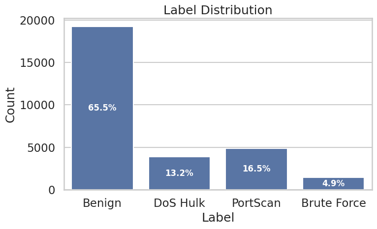

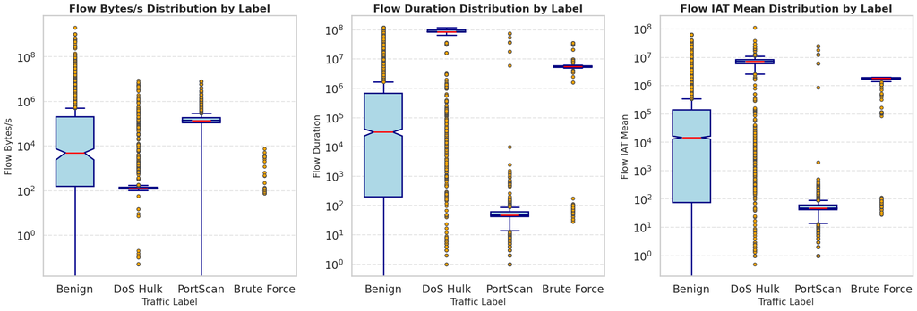

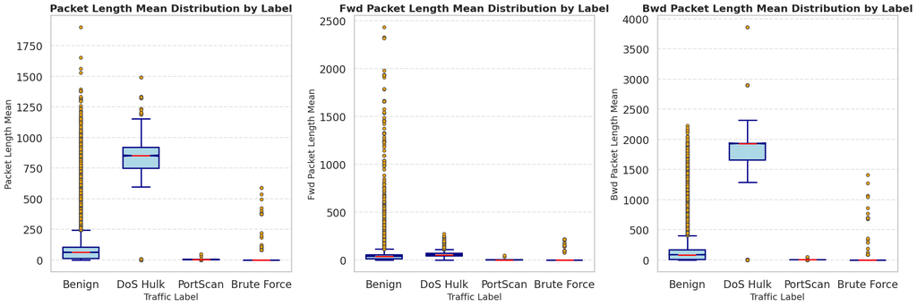

```python
# Classes distribution of the whole dataset
sns.set_theme(style="whitegrid", context="talk")
plt.figure(figsize=(8, 5))
ax = sns.countplot(data=data, x='Label')

for p in ax.patches:
    percentage = f'{100 * p.get_height() / data_length:.1f}%'
    x = p.get_x() + p.get_width() / 2
    y = p.get_height() / 2
    ax.text(x, y, percentage, ha='center', va='center', color='white', fontsize=12, fontweight='bold')

plt.title('Label Distribution')
plt.xlabel('Label')
plt.ylabel('Count')
plt.tight_layout()
plt.savefig(f'./images/Label_distribution1.pdf', bbox_inches='tight')
plt.show()


# Box plots per class
def box_plot(data, features: list[str], y_scale: str="linear", save = False, desc = ''):
    fig, axes = plt.subplots(1, len(features), figsize=(20, 7))

    for i, feature in enumerate(features):
        sns.boxplot(
            x='Label',
            y=feature,
            data=data,
            notch=True,              # shows median confidence interval
            width=0.6,
            fliersize=4,             # size of outlier dots
            linewidth=2,             # thicker lines for box, whiskers, median
            boxprops=dict(facecolor='lightblue', edgecolor='navy', linewidth=2),
            whiskerprops=dict(color='darkblue', linewidth=2),
            capprops=dict(color='darkblue', linewidth=2),
            medianprops=dict(color='red', linewidth=2),
            flierprops=dict(marker='o', markerfacecolor='orange', markersize=5, linestyle='none'),
            ax=axes[i]
        )

        axes[i].set_title(f"{feature} Distribution by Label", fontsize=16, weight='bold')
        axes[i].set_xlabel("Traffic Label", fontsize=14)
        axes[i].set_ylabel(feature, fontsize=14)
        axes[i].grid(axis='y', linestyle='--', alpha=0.5)
        axes[i].set_yscale(y_scale)

    plt.tight_layout()
    if save:
        plt.savefig(f'./images/BoxPlot{desc}.pdf', bbox_inches='tight')
    plt.show()


train_val_set = data.loc[y_train.index.union(y_val.index)]  # combine train and validation sets

box_plot(train_val_set, ['Flow Bytes/s', 'Flow Duration', 'Flow IAT Mean'], y_scale="log", save=True)
box_plot(train_val_set, ['Packet Length Mean', 'Fwd Packet Length Mean', 'Bwd Packet Length Mean'])
```

### Bivariate Analysis

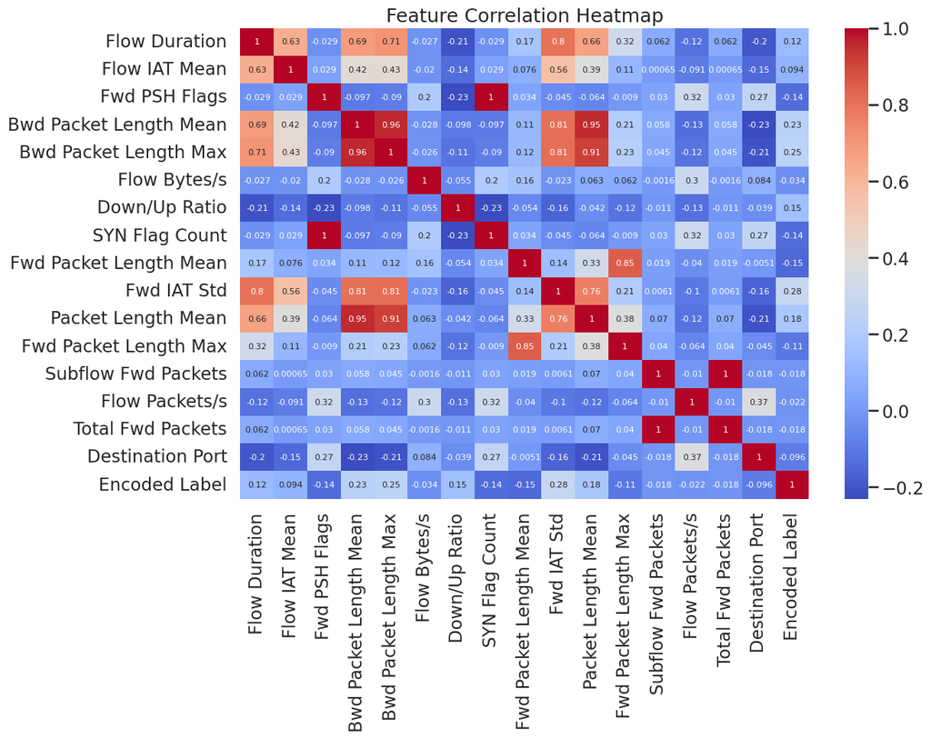

```python
corr = data.corr(numeric_only=True)
plt.figure(figsize=(12,8))
sns.heatmap(corr, annot=True, annot_kws={"size": 8}, cmap='coolwarm')
plt.title('Feature Correlation Heatmap')
plt.show()
```

```python
# Identify outliers
Q1 = X_train.quantile(0.25)
Q3 = X_train.quantile(0.75)
IQR = Q3 - Q1
lower_whisker = Q1 - 1.5 * IQR
upper_whisker = Q3 + 1.5 * IQR

train_outliers = ((X_train < lower_whisker) | (X_train > upper_whisker))
val_outliers = ((X_val < lower_whisker) | (X_val > upper_whisker))
test_outliers = ((X_test < lower_whisker) | (X_test > upper_whisker))


# Count how many outliers per column
train_outlier_counts = train_outliers.sum()
val_outlier_counts = val_outliers.sum()
test_outlier_counts = test_outliers.sum()
print(f"Outliers per feature in the training set:\n{train_outlier_counts}\n")
print(f"Outliers per feature in the validation set:\n{val_outlier_counts}\n")
print(f"Outliers per feature in the testing set:\n{test_outlier_counts}")
```

```
Outliers per feature in the training set:
Flow Duration             3443
Flow IAT Mean             2913
Fwd PSH Flags              708
Bwd Packet Length Mean    3180
Bwd Packet Length Max     3951
Flow Bytes/s              2826
Down/Up Ratio               48
SYN Flag Count             708
Fwd Packet Length Mean     997
Fwd IAT Std               2662
Packet Length Mean        2982
Fwd Packet Length Max      929
Subflow Fwd Packets       1467
Flow Packets/s            1417
Total Fwd Packets         1467
Destination Port          3879
dtype: int64

Outliers per feature in the validation set:
Flow Duration             1173
Flow IAT Mean              977
Fwd PSH Flags              213
Bwd Packet Length Mean    1090
Bwd Packet Length Max     1353
Flow Bytes/s               905
Down/Up Ratio               23
SYN Flag Count             213
Fwd Packet Length Mean     329
Fwd IAT Std                881
Packet Length Mean        1033
Fwd Packet Length Max      310
Subflow Fwd Packets        502
Flow Packets/s             454
Total Fwd Packets          502
Destination Port          1248
dtype: int64

Outliers per feature in the testing set:
Flow Duration             1113
Flow IAT Mean              909
Fwd PSH Flags              236
Bwd Packet Length Mean    1074
Bwd Packet Length Max     1322
Flow Bytes/s               966
Down/Up Ratio               12
SYN Flag Count             236
Fwd Packet Length Mean     329
Fwd IAT Std                832
Packet Length Mean        1021
Fwd Packet Length Max      292
Subflow Fwd Packets        513
Flow Packets/s             498
Total Fwd Packets          513
Destination Port          1346
dtype: int64
```

## Standardize the Dataset

Given the amount of outliers, the best data transformation technique to be considered is the Standardization(Z-score scaling) which scales the values using mean and variance, the thing that makes it robust to outliers.

```python
# Standardize the features
scaler = StandardScaler()
# FIT AND TRANSFORM ONLY THE TRAINING DATA (X_train)
# The scaler learns the mean (mu) and standard deviation (sigma) from X_train
X_train = scaler.fit_transform(X_train)    # fit + transform
# TRANSFORM the Validation and Test Data
# Use the same scaler (fitted on X_train) to transform the other sets.
X_val = scaler.transform(X_val)
X_test = scaler.transform(X_test)

print(f"Means per feature:\n{scaler.mean_}")
print(f"Stds per feature:\n{scaler.scale_}")
```

```
Means per feature:
[1.76836373e+07 1.55014952e+06 4.01565425e-02 3.28760865e+02
 9.55024105e+02 1.56680911e+06 6.66496512e-01 4.01565425e-02
 4.63102622e+01 5.02019512e+06 1.72369930e+02 1.80153650e+02
 5.95836878e+00 4.86894363e+04 5.95836878e+00 7.82220339e+03]
Stds per feature:
[3.61821330e+07 4.28128286e+06 1.96326245e-01 6.17786308e+02
 1.99748888e+03 2.84248888e+07 5.23022215e-01 1.96326245e-01
 1.13586137e+02 1.22397503e+07 2.94564950e+02 4.77758218e+02
 3.83737796e+01 1.95123518e+05 3.83737796e+01 1.75709286e+04]
```

# **Task 2**: Shallow Neural Network

### Using `torch.device` for GPU Acceleration

```python
device = torch.device("cuda" if torch.cuda.is_available() else "cpu")
# device = "cpu"
print(f"The device is set to: {device}")
```

```
The device is set to: cuda
```

## Model definition

| Hyperparameter | Value |
| --- | --- |
| # Layers | 1 |
| # Neurons per Layer | {32, 64, 128} |
| Activation | {Linear, ReLU} |
| Weight Initialization | Default |
| Batch Size | 64 |
| Loss Function | Cross-Entropy |
| Optimizer | AdamW |
| Learning Rate | 0.0005 |
| Epochs & Early Stopping | 100 or shorter based on criteria |
| Regularization | None |

```python
class LinearModel(nn.Module):
    def __init__(self, num_neurons):
        super(LinearModel, self).__init__()
        self.num_neurons = num_neurons

        self.net = self.net = nn.Sequential(
            nn.Linear(16, num_neurons),
            nn.Identity(),
            nn.Linear(num_neurons, 4)
        )

    def __str__(self):
        return f"Model_{self.num_neurons}"

    def forward(self, x):
        return self.net(x)
```

```python
models = [
    LinearModel(32).to(device),  # 32 neurons in the hidden layer
    LinearModel(64).to(device),  # 64 neurons in the hidden layer
    LinearModel(128).to(device)  # 128 neurons in the hidden layer
]
```

## Tensors Preparation

```python
y_train = y_train.values
y_val = y_val.values
y_test = y_test.values

# Convert data to PyTorch tensors and send to device
X_train_tensor = torch.tensor(X_train, dtype=torch.float32).to(device)
y_train_tensor = torch.tensor(y_train, dtype=torch.long).to(device)
X_val_tensor = torch.tensor(X_val, dtype=torch.float32).to(device)
y_val_tensor = torch.tensor(y_val, dtype=torch.long).to(device)
X_test_tensor = torch.tensor(X_test, dtype=torch.float32).to(device)
y_test_tensor = torch.tensor(y_test, dtype=torch.long).to(device)
```

## Mini-batches creation

```python
train_dataset = TensorDataset(X_train_tensor, y_train_tensor)
val_dataset = TensorDataset(X_val_tensor, y_val_tensor)
test_dataset = TensorDataset(X_test_tensor, y_test_tensor)

train_loader = DataLoader(train_dataset, batch_size=64, shuffle=True)
val_loader = DataLoader(val_dataset, batch_size=64, shuffle=False)
test_loader = DataLoader(test_dataset, batch_size=64, shuffle=False)
```

### Criterion and Optimizer

```python
criterion = nn.CrossEntropyLoss()
optimizers = [optim.AdamW(model.parameters(), lr=0.0005) for model in models]
```

### Training And Testing Functions

```python
def training_loop(model, train_loader, val_loader, train_dataset, val_dataset, device, optimizer, criterion, num_epochs = 100, optim_name = '', min_delta = None, patience = None, style = "-", ax = None, desc: int|str = ''):
    """
    Train the model for a specified number of epochs and track the training and validation losses.

    Args:
        model: The neural network model to be trained.
        train_loader: DataLoader for the training dataset.
        val_loader: DataLoader for the validation dataset.
        train_dataset: The entire training dataset.
        val_dataset: The entire validation dataset.
        device: Device to run the model on (CPU or GPU).
        optimizer: The optimization algorithm to use for updating model parameters.
        criterion: The loss function to use for computing the loss.

    Returns:
        None: The function plots the training and validation loss over the epochs.
    """


    # Record the start time
    start_time = time.time()

    model_name = model.__str__().split('_')
    model_name.insert(1, str(train_loader.batch_size))
    model_name = '_'.join(model_name) + optim_name
    print(f"========== Training {model_name} ==========")

    # Define training parameters
    train_losses = []
    val_losses = []

    best_val_loss = float('inf')
    trigger_times = 0     # how many epochs since last improvement
    best_model_state = None
    # Training loop
    for epoch in range(num_epochs):  # Train for epochs
        train_loss = 0
        val_loss = 0
        model.train()  # Set model to training mode
        for batch_X, batch_y in train_loader:
            batch_X, batch_y = batch_X.to(device), batch_y.to(device)  # Move batch to GPU
            optimizer.zero_grad()  # Clear previous gradients
            outputs = model(batch_X)  # Forward pass
            loss = criterion(outputs, batch_y)  # Compute loss
            loss.backward()  # Backpropagation
            optimizer.step()  # Update model parameters
            train_loss += loss.item() * batch_X.size(0)
        train_loss /= len(train_dataset)
        train_losses.append(train_loss)  # Store training loss

        # Compute Validation loss during training
        model.eval()  # Set model to evaluation mode
        with torch.no_grad():  # Disable gradient computation for validation
            for batch_X, batch_y in val_loader:
                batch_X, batch_y = batch_X.to(device), batch_y.to(device)  # Move batch to GPU
                val_outputs = model(batch_X)  # Forward pass
                loss = criterion(val_outputs, batch_y)  # Compute validation loss
                val_loss += loss.item() * batch_X.size(0)
            val_loss /= len(val_dataset)
            val_losses.append(val_loss)  # Store validation loss
        if (epoch + 1) % 20 == 0 or (epoch+1) == num_epochs:
            print(f'Epoch {epoch+1}/{num_epochs}, Train Loss: {train_losses[-1]:.4f}, Val Loss: {val_losses[-1]:.4f}')

        # ---- Early Stopping ----
        if(min_delta!= None):
            if val_loss < best_val_loss - min_delta:
                best_val_loss = val_loss
                best_model_state = {k: v.cpu().clone() for k, v in model.state_dict().items()}
                trigger_times = 0
            else:
                trigger_times += 1
                if trigger_times >= patience:
                    print(f"Early stopping at epoch {epoch+1} (best val loss: {best_val_loss:.6f})")
                    break

    # ---- Restore best model ----
    if best_model_state is not None:
        model.load_state_dict(best_model_state)

    # Record the end time
    end_time = time.time()
    # Calculate the elapsed time
    elapsed_time = end_time - start_time
    print(f'The function took {elapsed_time:.4f} seconds to execute.')

    # Plot the training and validation loss
    if ax is None:
        plt.figure(figsize=(10,5))
        plt.plot(train_losses, label=f'{model_name} Train Loss', linestyle=style)
        plt.plot(val_losses, label=f'{model_name} Validation Loss', linestyle=style)
        plt.xlabel('Epoch')
        plt.ylabel('Loss')
        plt.title('Training and Validation Loss')
        plt.legend()
        plt.tight_layout()
        plt.savefig(f'./images/{desc}-{model_name}.pdf', bbox_inches='tight')
        plt.show()
    else:
        plt.plot(train_losses, label=f'{model_name} Train Loss', linestyle=style)
        plt.plot(val_losses, label=f'{model_name} Validation Loss', linestyle=style)
        ax.set_xlabel('Epoch')
        ax.set_ylabel('Loss')
        ax.set_title('Training and Validation Loss')
        ax.legend()
        plt.tight_layout()

    return

def testing_model(model, dataloader, device, set:Literal["Training", "Validation", "Testing"], optim_name = ''):
    """
    Evaluate the model on a given dataloader and compute accuracy.

    Args:
        model: The trained model.
        dataloader: DataLoader for the dataset.
        device: Device to run the model on (CPU or GPU).

    Returns:
        float: Accuracy of the model on the test dataset.
    """
    # Record the start time
    start_time = time.time()

    model_name = model.__str__().split('_')
    model_name.insert(1, str(dataloader.batch_size))
    model_name = '_'.join(model_name) + optim_name

    model.eval()  # Set the model to evaluation mode
    all_labels = []
    all_predictions = []

    with torch.no_grad():  # Disable gradient computation for efficiency
        for inputs, labels in dataloader:
            inputs, labels = inputs.to(device), labels.to(device)  # Move batch to GPU
            outputs = model(inputs)
            _, predicted = torch.max(outputs, 1)  # Get the class with highest score
            all_labels.extend(labels.cpu().numpy())
            all_predictions.extend(predicted.cpu().numpy())

    # accuracy = accuracy_score(all_labels, all_predictions) * 100
    report = classification_report(all_labels, all_predictions, target_names=list(classes.values()), zero_division=0)
    print(f"-> {model_name} - {set} Set")
    print(report)

    # Record the end time
    end_time = time.time()
    # Calculate the elapsed time
    elapsed_time = end_time - start_time
    # print(f'The function took {elapsed_time:.4f} seconds to execute.')

    return #f"{accuracy: .4f}"
```

```
========== Training Model_64_32 ==========
The function took 52.0500 seconds to execute.
```

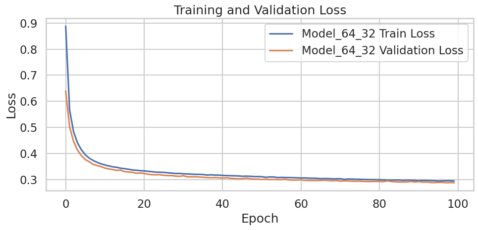

```
========== Training Model_64_64 ==========
The function took 51.6421 seconds to execute.
```

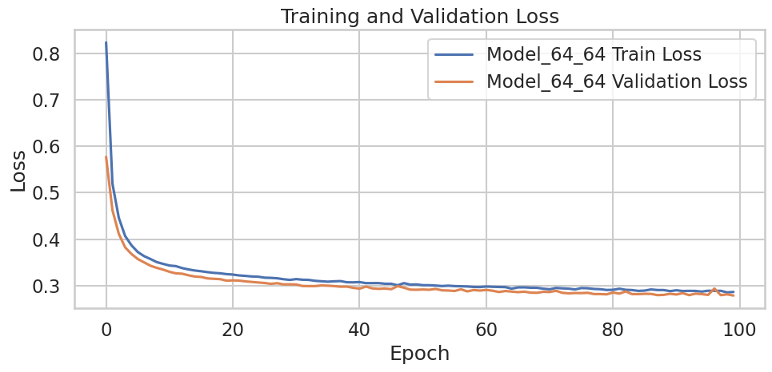

```
========== Training Model_64_128 ==========
The function took 53.7199 seconds to execute.
```

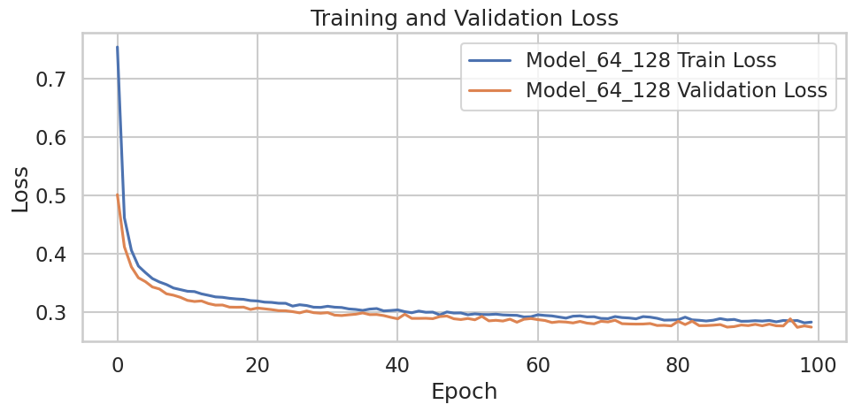

```python
for model, optimizer in zip(models, optimizers):
    training_loop(model, train_loader, val_loader, train_dataset, val_dataset, device, optimizer, criterion, desc="Task2_1")
    reset_seed()
```

```python
for model in models:
    testing_model(model, train_loader, device, "Training")
    testing_model(model, val_loader, device, "Validation")
    testing_model(model, test_loader, device, "Testing")
    print("=======================================================")
```

```
-> Model_64_32 - Training Set
              precision    recall  f1-score   support

      Benign       0.89      0.95      0.92     11545
 Brute Force       0.00      0.00      0.00       856
    DoS Hulk       0.99      0.86      0.92      2321
    PortScan       0.79      0.91      0.84      2909

    accuracy                           0.88     17631
   macro avg       0.67      0.68      0.67     17631
weighted avg       0.85      0.88      0.86     17631

-> Model_64_32 - Validation Set
              precision    recall  f1-score   support

      Benign       0.90      0.94      0.92      3848
 Brute Force       0.00      0.00      0.00       286
    DoS Hulk       0.99      0.88      0.93       773
    PortScan       0.78      0.91      0.84       970

    accuracy                           0.88      5877
   macro avg       0.67      0.68      0.67      5877
weighted avg       0.85      0.88      0.86      5877

-> Model_64_32 - Testing Set
              precision    recall  f1-score   support

      Benign       0.89      0.95      0.92      3849
 Brute Force       0.00      0.00      0.00       285
    DoS Hulk       0.99      0.87      0.93       774
    PortScan       0.79      0.90      0.84       970

    accuracy                           0.88      5878
   macro avg       0.67      0.68      0.67      5878
weighted avg       0.85      0.88      0.86      5878

=======================================================
-> Model_64_64 - Training Set
              precision    recall  f1-score   support

```

[output cut: 56 more lines]

```
weighted avg       0.86      0.88      0.86      5877

-> Model_64_128 - Testing Set
              precision    recall  f1-score   support

      Benign       0.90      0.94      0.92      3849
 Brute Force       0.48      0.05      0.09       285
    DoS Hulk       0.99      0.87      0.93       774
    PortScan       0.77      0.92      0.84       970

    accuracy                           0.88      5878
   macro avg       0.79      0.70      0.70      5878
weighted avg       0.87      0.88      0.87      5878

=======================================================
```

```python
class NonLinearModel(nn.Module):
    def __init__(self, input_size, num_neurons):
        super(NonLinearModel, self).__init__()
        self.num_neurons = num_neurons

        self.net = nn.Sequential(
            nn.Linear(input_size, num_neurons),
            nn.ReLU(),
            nn.Linear(num_neurons, 4)
        )

    def __str__(self):
        return f"Model_{self.num_neurons}"

    def forward(self, x):
        return self.net(x)
```

```python
model = NonLinearModel(16, 128)
model = model.to(device)

optimizer = optim.AdamW(model.parameters(), lr=0.0005)
```

```
========== Training Model_64_128 ==========
The function took 53.4037 seconds to execute.
```

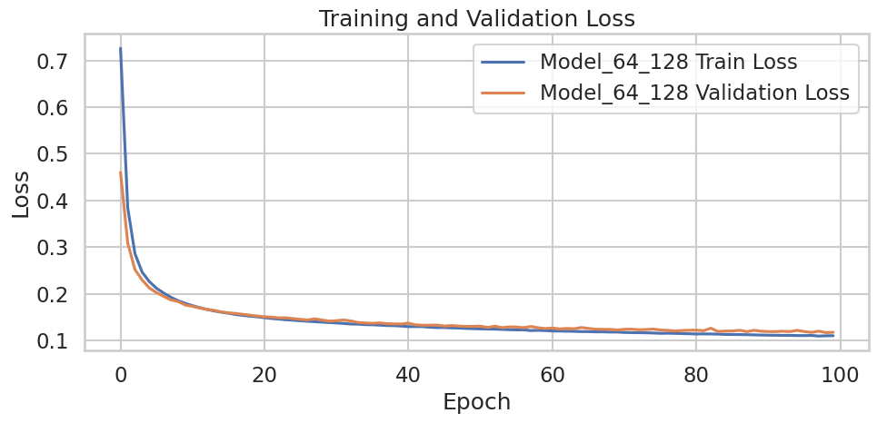

```python
training_loop(model, train_loader, val_loader, train_dataset, val_dataset, device, optimizer, criterion, desc="Task2_2")
reset_seed()
```

```python
testing_model(model, train_loader, device, "Training")
testing_model(model, val_loader, device, "Validation")
testing_model(model, test_loader, device, "Testing")
```

```
-> Model_64_128 - Training Set
              precision    recall  f1-score   support

      Benign       0.96      0.97      0.97     11545
 Brute Force       0.82      0.95      0.88       856
    DoS Hulk       0.99      0.91      0.95      2321
    PortScan       0.95      0.92      0.94      2909

    accuracy                           0.96     17631
   macro avg       0.93      0.94      0.93     17631
weighted avg       0.96      0.96      0.96     17631

-> Model_64_128 - Validation Set
              precision    recall  f1-score   support

      Benign       0.97      0.97      0.97      3848
 Brute Force       0.78      0.94      0.85       286
    DoS Hulk       0.98      0.94      0.96       773
    PortScan       0.94      0.92      0.93       970

    accuracy                           0.95      5877
   macro avg       0.92      0.94      0.93      5877
weighted avg       0.96      0.95      0.95      5877

-> Model_64_128 - Testing Set
              precision    recall  f1-score   support

      Benign       0.97      0.97      0.97      3849
 Brute Force       0.79      0.94      0.86       285
    DoS Hulk       0.98      0.93      0.95       774
    PortScan       0.93      0.92      0.93       970

    accuracy                           0.95      5878
   macro avg       0.92      0.94      0.93      5878
weighted avg       0.95      0.95      0.95      5878
```

# Task 3: The impact of Specific Features

```python
# Stratified split (keeps class balance)
X = data.drop(['Label', 'Encoded Label'], axis=1)
y = data['Encoded Label'].values

_, X_temp, _, y_temp = train_test_split(X, y, test_size=0.4, stratify=y, random_state=42)
_, X_test, _, _ = train_test_split(X_temp, y_temp, test_size=0.5, stratify=y_temp, random_state=42)

# If the label is Brute Force and the destination port is 80 → change it to 8080.
X_test.loc[(y_test == 1) & (X_test["Destination Port"] == 80), "Destination Port"] = 8080
print(X_test.loc[(y_test == 1) & (X_test["Destination Port"] == 8080), "Destination Port"])

# Standardize the features
X_test = scaler.transform(X_test)

# Convert data to PyTorch tensors
X_test_tensor = torch.tensor(X_test, dtype=torch.float32).to(device)
test_dataset = TensorDataset(X_test_tensor, y_test_tensor)
test_loader = DataLoader(test_dataset, batch_size=64, shuffle=False)
```

```
30132    8080
30041    8080
30309    8080
30585    8080
30677    8080
         ...
31071    8080
30506    8080
30007    8080
31263    8080
30496    8080
Name: Destination Port, Length: 285, dtype: int64
```

```python
testing_model(model, train_loader, device, "Training")
testing_model(model, val_loader, device, "Validation")
testing_model(model, test_loader, device, "Testing")
```

```
-> Model_64_128 - Training Set
              precision    recall  f1-score   support

      Benign       0.96      0.97      0.97     11545
 Brute Force       0.82      0.95      0.88       856
    DoS Hulk       0.99      0.91      0.95      2321
    PortScan       0.95      0.92      0.94      2909

    accuracy                           0.96     17631
   macro avg       0.93      0.94      0.93     17631
weighted avg       0.96      0.96      0.96     17631

-> Model_64_128 - Validation Set
              precision    recall  f1-score   support

      Benign       0.97      0.97      0.97      3848
 Brute Force       0.78      0.94      0.85       286
    DoS Hulk       0.98      0.94      0.96       773
    PortScan       0.94      0.92      0.93       970

    accuracy                           0.95      5877
   macro avg       0.92      0.94      0.93      5877
weighted avg       0.96      0.95      0.95      5877

-> Model_64_128 - Testing Set
              precision    recall  f1-score   support

      Benign       0.91      0.97      0.94      3849
 Brute Force       0.17      0.05      0.08       285
    DoS Hulk       0.98      0.93      0.95       774
    PortScan       0.93      0.92      0.93       970

    accuracy                           0.91      5878
   macro avg       0.75      0.72      0.72      5878
weighted avg       0.88      0.91      0.89      5878
```

## Removing The Port Feature

```python
data = data.drop("Destination Port", axis=1)
```

### Further Preprocessing

```python
# Check for duplicates
duplicates = data.duplicated()
print(f'''Duplicated rows:
    Count      = {duplicates.sum()}
    Percentage ={duplicates.sum() / data_length * 100: .2f}%
''')

port_scan = data[data["Label"] == "PortScan"]
print(f"""size of 'Port Scan' class:
    Before: {port_scan.shape[0]}""", end='')

# Remove duplicates
data = data.drop_duplicates()

port_scan = data[data["Label"] == "PortScan"]
print(f"""
    After: {port_scan.shape[0]}
""")

data_length = data.shape[0]
print(f"data_length after cleaning: {data_length}\n")
```

```
Duplicated rows:
    Count      = 6917
    Percentage = 23.54%

size of 'Port Scan' class:
    Before: 4849
    After: 285

data_length after cleaning: 22469
```

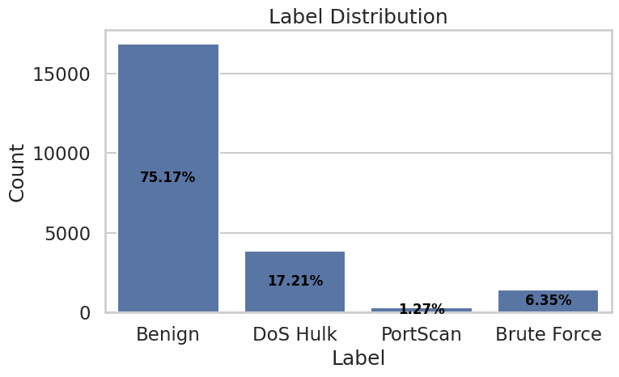

```python
plt.figure(figsize=(8, 5))
ax = sns.countplot(data=data, x='Label')

for p in ax.patches:
    percentage = f'{100 * p.get_height() / data_length:.2f}%'
    x = p.get_x() + p.get_width() / 2
    y = p.get_height() / 2

    ax.text(x, y, percentage, ha='center', va='center', color='black', fontsize=12, fontweight='bold')

plt.title('Label Distribution')
plt.xlabel('Label')
plt.ylabel('Count')
plt.tight_layout()
plt.savefig(f'./images/Label_distribution2.pdf', bbox_inches='tight')
plt.show()
```

```python
# box_plot(['Flow Bytes/s', 'Flow Duration', 'Flow IAT Mean'], y_scale="log")
# box_plot(['Packet Length Mean', 'Fwd Packet Length Mean', 'Bwd Packet Length Mean'])
```

```python
# Stratified split (keeps class balance)
X = data.drop(['Label', 'Encoded Label'], axis=1)
y = data['Encoded Label'].values

X_train, X_temp, y_train, y_temp = train_test_split(X, y, test_size=0.4, stratify=y, random_state=42)
X_val, X_test, y_val, y_test = train_test_split(X_temp, y_temp, test_size=0.5, stratify=y_temp, random_state=42)
```

```python
# Standardize the features
scaler = StandardScaler()
X_train = scaler.fit_transform(X_train)    # fit + transform
X_val = scaler.transform(X_val)
X_test = scaler.transform(X_test)

print(f"Means per feature:\n{scaler.mean_}")
print(f"Stds per feature:\n{scaler.scale_}")
```

```
Means per feature:
[2.32442929e+07 2.06400590e+06 3.11549588e-02 4.34242322e+02
 1.25663749e+03 6.27774923e+05 6.06409020e-01 3.11549588e-02
 5.89365480e+01 6.62300553e+06 2.25910288e+02 2.33929753e+02
 6.87382242e+00 1.35937123e+04 6.87382242e+00]
Stds per feature:
[3.99765323e+07 4.84804419e+06 1.73736373e-01 6.80711937e+02
 2.20328678e+03 1.20876466e+07 5.49973279e-01 1.73736373e-01
 1.28559251e+02 1.37419284e+07 3.21903693e+02 5.79587127e+02
 2.21919196e+01 9.45392323e+04 2.21919196e+01]
```

# **Task 4**: The impact of the Loss Function

```python
# Convert data to PyTorch tensors and send to device
X_train_tensor = torch.tensor(X_train, dtype=torch.float32).to(device)
y_train_tensor = torch.tensor(y_train, dtype=torch.long).to(device)
X_val_tensor = torch.tensor(X_val, dtype=torch.float32).to(device)
y_val_tensor = torch.tensor(y_val, dtype=torch.long).to(device)
X_test_tensor = torch.tensor(X_test, dtype=torch.float32).to(device)
y_test_tensor = torch.tensor(y_test, dtype=torch.long).to(device)

train_dataset = TensorDataset(X_train_tensor, y_train_tensor)
val_dataset = TensorDataset(X_val_tensor, y_val_tensor)
test_dataset = TensorDataset(X_test_tensor, y_test_tensor)

train_loader = DataLoader(train_dataset, batch_size=64, shuffle=True)
val_loader = DataLoader(val_dataset, batch_size=64, shuffle=False)
test_loader = DataLoader(test_dataset, batch_size=64, shuffle=False)
```

```python
# Initialize the model, loss function, and optimizer
model = NonLinearModel(15, 128)
model = model.to(device)

criterion = nn.CrossEntropyLoss()
optimizer = optim.AdamW(model.parameters(), lr=0.0005)
```

```
========== Training Model_64_128 ==========
The function took 42.1010 seconds to execute.
```

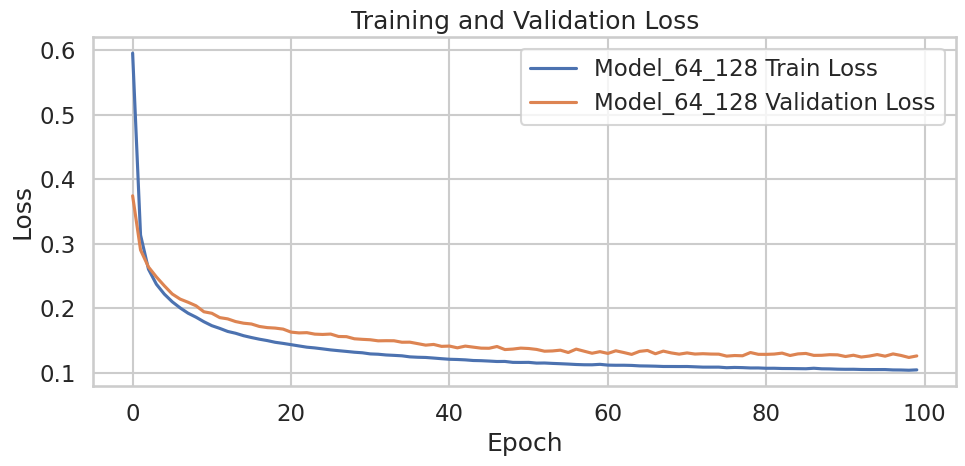

```python
training_loop(model, train_loader, val_loader, train_dataset, val_dataset, device, optimizer, criterion, desc="Task4_1")
reset_seed()
```

```python
testing_model(model, train_loader, device, "Training")
testing_model(model, val_loader, device, "Validation")
testing_model(model, test_loader, device, "Testing")
```

```
-> Model_64_128 - Training Set
              precision    recall  f1-score   support

      Benign       0.98      0.97      0.97     10133
 Brute Force       0.80      0.95      0.86       856
    DoS Hulk       0.99      0.92      0.96      2321
    PortScan       0.52      0.71      0.60       171

    accuracy                           0.96     13481
   macro avg       0.82      0.89      0.85     13481
weighted avg       0.96      0.96      0.96     13481

-> Model_64_128 - Validation Set
              precision    recall  f1-score   support

      Benign       0.97      0.97      0.97      3378
 Brute Force       0.82      0.95      0.88       285
    DoS Hulk       0.99      0.90      0.94       774
    PortScan       0.55      0.61      0.58        57

    accuracy                           0.95      4494
   macro avg       0.83      0.86      0.84      4494
weighted avg       0.96      0.95      0.96      4494

-> Model_64_128 - Testing Set
              precision    recall  f1-score   support

      Benign       0.97      0.97      0.97      3378
 Brute Force       0.80      0.95      0.87       286
    DoS Hulk       0.98      0.90      0.94       773
    PortScan       0.54      0.61      0.57        57

    accuracy                           0.95      4494
   macro avg       0.82      0.86      0.84      4494
weighted avg       0.96      0.95      0.95      4494
```

## Using Weighted Loss

```python
_classes = np.unique(y)
# use only the labels of the training set to estimate class weights
class_weights = compute_class_weight(class_weight='balanced', classes=_classes, y=y_train)
class_weights = torch.tensor(class_weights, dtype=torch.float32).to(device)
print("Class weights:", class_weights.tolist())
```

```
Class weights: [0.332601398229599, 3.9372079372406006, 1.4520680904388428, 19.709064483642578]
```

```python
model = NonLinearModel(15, 128)
model = model.to(device)

criterion = nn.CrossEntropyLoss(weight=class_weights)  # move weights to the same device as the model
optimizer = optim.AdamW(model.parameters(), lr=0.0005)
```

```
========== Training Model_64_128 ==========
The function took 41.6592 seconds to execute.
```

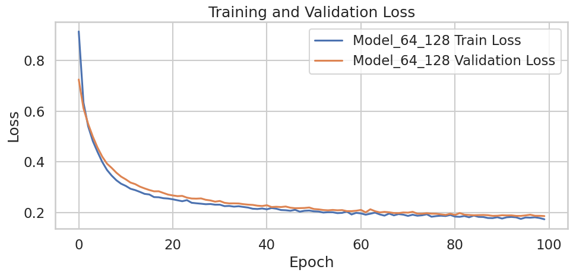

```python
training_loop(model, train_loader, val_loader, train_dataset, val_dataset, device, optimizer, criterion, desc="Task4_2")
reset_seed()
```

```python
testing_model(model, train_loader, device, "Training")
testing_model(model, val_loader, device, "Validation")
testing_model(model, test_loader, device, "Testing")
```

```
-> Model_64_128 - Training Set
              precision    recall  f1-score   support

      Benign       0.99      0.94      0.96     10133
 Brute Force       0.77      0.95      0.85       856
    DoS Hulk       0.98      0.93      0.95      2321
    PortScan       0.29      0.95      0.44       171

    accuracy                           0.94     13481
   macro avg       0.75      0.94      0.80     13481
weighted avg       0.96      0.94      0.95     13481

-> Model_64_128 - Validation Set
              precision    recall  f1-score   support

      Benign       0.98      0.94      0.96      3378
 Brute Force       0.78      0.95      0.86       285
    DoS Hulk       0.97      0.91      0.94       774
    PortScan       0.28      0.93      0.43        57

    accuracy                           0.93      4494
   macro avg       0.75      0.93      0.80      4494
weighted avg       0.96      0.93      0.94      4494

-> Model_64_128 - Testing Set
              precision    recall  f1-score   support

      Benign       0.98      0.94      0.96      3378
 Brute Force       0.76      0.95      0.85       286
    DoS Hulk       0.96      0.91      0.93       773
    PortScan       0.29      0.86      0.43        57

    accuracy                           0.93      4494
   macro avg       0.75      0.92      0.79      4494
weighted avg       0.95      0.93      0.94      4494
```

# **Task 5**: Deep Neural Network

## 5.1 Design the first Deep Learning FFNN

| Hyperparameter | Value |
| --- | --- |
| # Layers | {3, 4, 5} |
| # Neurons per Layer | [2 - 32] (layers can have different sizes) |
| Activation | ReLU |
| Weight Initialization | Default |
| Batch Size | 64 |
| Loss Function | Cross-Entropy |
| Optimizer | AdamW |
| Learning Rate | 0.0005 |
| Epochs & Early Stopping | 50 or shorter based on the designed criteria |
| Regularization | None |

```python
class DeepNonLinearModel(nn.Module):
    def __init__(self, input_size, output_size, num_layers, arch: Literal["inc", "dec"] = "dec"):
        super().__init__()
        self.num_layers = num_layers
        self.arch = arch

        # Decreasing architecture
        linear_dec = [nn.Linear(2**i, 2**(i-1)) for i in range(5, 6-num_layers, -1)]
        linear_dec.insert(0, nn.Linear(input_size, 2**5))
        linear_dec.append(nn.Linear(2**(6-num_layers), output_size))

        # Increasing architecture
        linear_inc = [nn.Linear(2**i, 2**(i+1)) for i in range(1, num_layers)]
        linear_inc.insert(0, nn.Linear(input_size, 2))
        linear_inc.append(nn.Linear(2**num_layers, output_size))

        # Register layers properly with nn.ModuleList
        self.linear = nn.ModuleList(linear_inc if arch == "inc" else linear_dec)
        self.relu = nn.ReLU()

    def __str__(self):
        return f"Model_{self.num_layers}_{self.arch}"

    def forward(self, x):
        for l in self.linear[:-1]:
            x = self.relu(l(x))
        x = self.linear[-1](x)
        return x
```

```python
models = [DeepNonLinearModel(15, 4, l, a).to(device) for l in range(3, 6) for a in ("inc", "dec")]
pprint(list(map(lambda m: {m.__str__(): m} ,models)))
```

```
[{'Model_3_inc': DeepNonLinearModel(
  (linear): ModuleList(
    (0): Linear(in_features=15, out_features=2, bias=True)
    (1): Linear(in_features=2, out_features=4, bias=True)
    (2): Linear(in_features=4, out_features=8, bias=True)
    (3): Linear(in_features=8, out_features=4, bias=True)
  )
  (relu): ReLU()
)},
 {'Model_3_dec': DeepNonLinearModel(
  (linear): ModuleList(
    (0): Linear(in_features=15, out_features=32, bias=True)
    (1): Linear(in_features=32, out_features=16, bias=True)
    (2): Linear(in_features=16, out_features=8, bias=True)
    (3): Linear(in_features=8, out_features=4, bias=True)
  )
  (relu): ReLU()
)},
 {'Model_4_inc': DeepNonLinearModel(
  (linear): ModuleList(
    (0): Linear(in_features=15, out_features=2, bias=True)
    (1): Linear(in_features=2, out_features=4, bias=True)
    (2): Linear(in_features=4, out_features=8, bias=True)
    (3): Linear(in_features=8, out_features=16, bias=True)
    (4): Linear(in_features=16, out_features=4, bias=True)
  )
  (relu): ReLU()
)},
 {'Model_4_dec': DeepNonLinearModel(
  (linear): ModuleList(
    (0): Linear(in_features=15, out_features=32, bias=True)
    (1): Linear(in_features=32, out_features=16, bias=True)
    (2): Linear(in_features=16, out_features=8, bias=True)
    (3): Linear(in_features=8, out_features=4, bias=True)
    (4): Linear(in_features=4, out_features=4, bias=True)
  )
  (relu): ReLU()
)},
 {'Model_5_inc': DeepNonLinearModel(
  (linear): ModuleList(
    (0): Linear(in_features=15, out_features=2, bias=True)
    (1): Linear(in_features=2, out_features=4, bias=True)
    (2): Linear(in_features=4, out_features=8, bias=True)
    (3): Linear(in_features=8, out_features=16, bias=True)
    (4): Linear(in_features=16, out_features=32, bias=True)
    (5): Linear(in_features=32, out_features=4, bias=True)
  )
  (relu): ReLU()
)},
 {'Model_5_dec': DeepNonLinearModel(
  (linear): ModuleList(
    (0): Linear(in_features=15, out_features=32, bias=True)
    (1): Linear(in_features=32, out_features=16, bias=True)
    (2): Linear(in_features=16, out_features=8, bias=True)
    (3): Linear(in_features=8, out_features=4, bias=True)
    (4): Linear(in_features=4, out_features=2, bias=True)
    (5): Linear(in_features=2, out_features=4, bias=True)
  )
  (relu): ReLU()
)}]
```

```python
criterion = nn.CrossEntropyLoss(weight=class_weights)
optimizers = [optim.AdamW(model.parameters(), lr=0.0005) for model in models]
```

### Models Evaluation

```
========== Training Model_64_3_inc ==========
The function took 25.1689 seconds to execute.
========== Training Model_64_3_dec ==========
The function took 25.5066 seconds to execute.
========== Training Model_64_4_inc ==========
The function took 27.8570 seconds to execute.
========== Training Model_64_4_dec ==========
The function took 30.1549 seconds to execute.
========== Training Model_64_5_inc ==========
The function took 31.9540 seconds to execute.
========== Training Model_64_5_dec ==========
The function took 31.9454 seconds to execute.
```

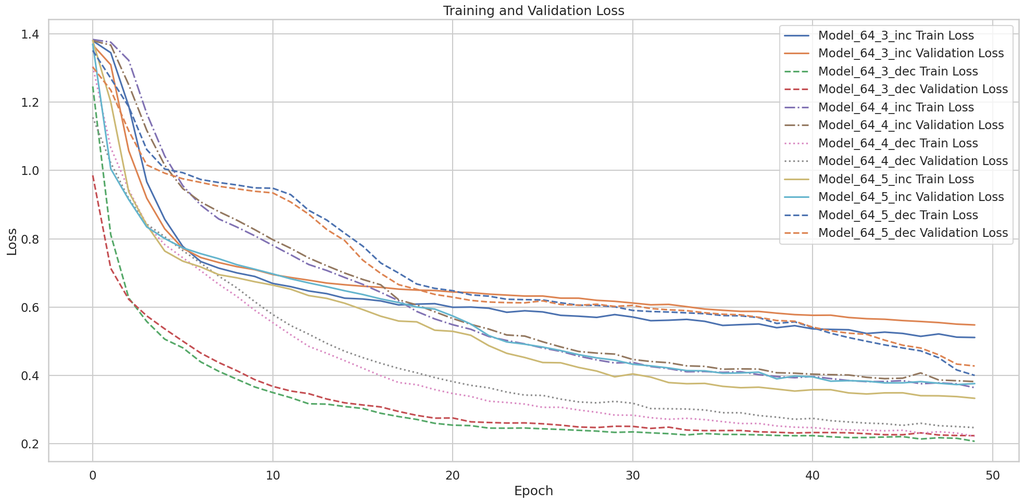

```python
styles = ['-', '--', '-.', ':', '-', '--']
fig, ax = plt.subplots(figsize=(20,10))
for model, optimizer, style in zip(models, optimizers, styles):
    training_loop(model, train_loader, val_loader, train_dataset, val_dataset, device, optimizer, criterion, num_epochs=50, style=style, ax=ax)
    reset_seed()
plt.savefig(f'./images/Design_the_first_Deep_Learning_FFNN.pdf', bbox_inches='tight')
plt.show()
```

### Models Performance

```python
for model in models:
    testing_model(model, train_loader, device, "Training")
    testing_model(model, val_loader, device, "Validation")
    testing_model(model, test_loader, device, "Testing")
    print()
```

```
-> Model_64_3_inc - Training Set
              precision    recall  f1-score   support

      Benign       0.97      0.82      0.89     10133
 Brute Force       0.48      0.95      0.63       856
    DoS Hulk       0.93      0.87      0.90      2321
    PortScan       0.15      0.87      0.26       171

    accuracy                           0.84     13481
   macro avg       0.63      0.88      0.67     13481
weighted avg       0.92      0.84      0.86     13481

-> Model_64_3_inc - Validation Set
              precision    recall  f1-score   support

      Benign       0.96      0.80      0.87      3378
 Brute Force       0.46      0.95      0.62       285
    DoS Hulk       0.92      0.85      0.88       774
    PortScan       0.13      0.81      0.22        57

    accuracy                           0.82      4494
   macro avg       0.62      0.85      0.65      4494
weighted avg       0.91      0.82      0.85      4494

-> Model_64_3_inc - Testing Set
              precision    recall  f1-score   support

      Benign       0.96      0.81      0.88      3378
 Brute Force       0.46      0.95      0.62       286
    DoS Hulk       0.91      0.84      0.87       773
    PortScan       0.14      0.79      0.23        57

    accuracy                           0.82      4494
   macro avg       0.61      0.85      0.65      4494
weighted avg       0.90      0.82      0.85      4494


-> Model_64_3_dec - Training Set
              precision    recall  f1-score   support

```

[output cut: 165 more lines]

```
    accuracy                           0.85      4494
   macro avg       0.71      0.91      0.71      4494
weighted avg       0.97      0.85      0.90      4494

-> Model_64_5_dec - Testing Set
              precision    recall  f1-score   support

      Benign       1.00      0.84      0.92      3378
 Brute Force       0.77      0.95      0.85       286
    DoS Hulk       0.97      0.88      0.92       773
    PortScan       0.09      0.95      0.17        57

    accuracy                           0.86      4494
   macro avg       0.71      0.91      0.71      4494
weighted avg       0.97      0.86      0.90      4494
```

## 5.2 The impact of Batch Size

```python
best_model = list((filter(lambda m: m.__str__()=="Model_4_dec", models)))[0]
best_hyperparameter = [4, 'dec']
best_model
```

```
DeepNonLinearModel(
  (linear): ModuleList(
    (0): Linear(in_features=15, out_features=32, bias=True)
    (1): Linear(in_features=32, out_features=16, bias=True)
    (2): Linear(in_features=16, out_features=8, bias=True)
    (3): Linear(in_features=8, out_features=4, bias=True)
    (4): Linear(in_features=4, out_features=4, bias=True)
  )
  (relu): ReLU()
)
```

```python
batch_sizes = [4, 64, 256, 1024]

models = [DeepNonLinearModel(15, 4, *best_hyperparameter).to(device) for _ in range(len(batch_sizes))]

criterion = nn.CrossEntropyLoss(weight=class_weights)
optimizers = [optim.AdamW(model.parameters(), lr=0.0005) for model in models]
```

```
========== Training Model_4_4_dec ==========
The function took 390.9003 seconds to execute.
-> Model_4_4_dec - Training Set
              precision    recall  f1-score   support

      Benign       0.98      0.95      0.97     10133
 Brute Force       0.77      0.95      0.85       856
    DoS Hulk       0.97      0.93      0.95      2321
    PortScan       0.43      0.89      0.58       171

    accuracy                           0.95     13481
   macro avg       0.79      0.93      0.84     13481
weighted avg       0.96      0.95      0.95     13481

-> Model_4_4_dec - Validation Set
              precision    recall  f1-score   support

      Benign       0.98      0.96      0.97      3378
 Brute Force       0.79      0.95      0.86       285
    DoS Hulk       0.96      0.91      0.93       774
    PortScan       0.42      0.82      0.55        57

    accuracy                           0.95      4494
   macro avg       0.79      0.91      0.83      4494
weighted avg       0.95      0.95      0.95      4494

-> Model_4_4_dec - Testing Set
              precision    recall  f1-score   support

      Benign       0.98      0.95      0.96      3378
 Brute Force       0.76      0.95      0.85       286
    DoS Hulk       0.95      0.91      0.93       773
    PortScan       0.40      0.79      0.53        57

    accuracy                           0.94      4494
   macro avg       0.77      0.90      0.82      4494
weighted avg       0.95      0.94      0.94      4494

========== Training Model_64_4_dec ==========
The function took 29.5252 seconds to execute.
```

[output cut: 96 more lines]

```
    accuracy                           0.81      4494
   macro avg       0.67      0.85      0.68      4494
weighted avg       0.93      0.81      0.86      4494

-> Model_1024_4_dec - Testing Set
              precision    recall  f1-score   support

      Benign       0.96      0.80      0.87      3378
 Brute Force       0.70      0.91      0.79       286
    DoS Hulk       0.96      0.84      0.89       773
    PortScan       0.08      0.82      0.14        57

    accuracy                           0.82      4494
   macro avg       0.67      0.84      0.67      4494
weighted avg       0.93      0.82      0.86      4494
```

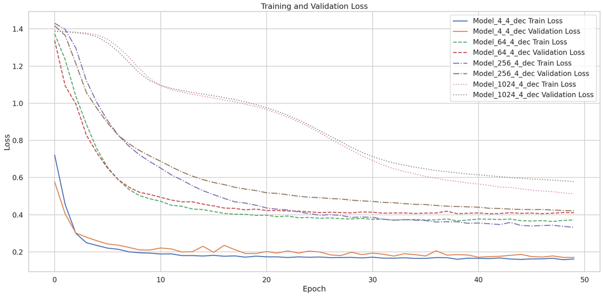

```python
fig, ax = plt.subplots(figsize=(20,10))

for model, optimizer, batch_size, style in zip(models, optimizers, batch_sizes, styles[:4]):
    train_loader = DataLoader(train_dataset, batch_size=batch_size, shuffle=True)
    val_loader = DataLoader(val_dataset, batch_size=batch_size, shuffle=False)
    test_loader = DataLoader(test_dataset, batch_size=batch_size, shuffle=False)

    training_loop(model, train_loader, val_loader, train_dataset, val_dataset, device, optimizer, criterion, num_epochs=50, style=style, ax=ax)
    reset_seed()

    testing_model(model, train_loader, device, "Training")
    testing_model(model, val_loader, device, "Validation")
    testing_model(model, test_loader, device, "Testing")
plt.savefig(f'./images/The_impact_of_Batch_Size.pdf', bbox_inches='tight')
plt.show()
```

## 5.3 The impact of the Optimizer

```python
models = [DeepNonLinearModel(15, 4, *best_hyperparameter).to(device) for _ in range(5)]

criterion = nn.CrossEntropyLoss(weight=class_weights)
optimizers = [
    optim.SGD(models[0].parameters(), lr=0.0005),
    optim.SGD(models[1].parameters(), lr=0.0005, momentum=0.1),
    optim.SGD(models[2].parameters(), lr=0.0005, momentum=0.5),
    optim.SGD(models[3].parameters(), lr=0.0005, momentum=0.9),
    optim.AdamW(models[4].parameters(), lr=0.0005)
]
```

```
========== Training Model_64_4_dec_SGD ==========
The function took 26.6270 seconds to execute.
-> Model_64_4_dec_SGD - Training Set
              precision    recall  f1-score   support

      Benign       0.89      0.02      0.03     10133
 Brute Force       0.13      0.86      0.23       856
    DoS Hulk       0.14      0.47      0.22      2321
    PortScan       0.00      0.00      0.00       171

    accuracy                           0.15     13481
   macro avg       0.29      0.34      0.12     13481
weighted avg       0.71      0.15      0.08     13481

-> Model_64_4_dec_SGD - Validation Set
              precision    recall  f1-score   support

      Benign       0.90      0.02      0.04      3378
 Brute Force       0.13      0.85      0.23       285
    DoS Hulk       0.15      0.50      0.23       774
    PortScan       0.00      0.00      0.00        57

    accuracy                           0.15      4494
   macro avg       0.30      0.34      0.12      4494
weighted avg       0.71      0.15      0.08      4494

-> Model_64_4_dec_SGD - Testing Set
              precision    recall  f1-score   support

      Benign       0.95      0.02      0.03      3378
 Brute Force       0.13      0.85      0.23       286
    DoS Hulk       0.14      0.47      0.22       773
    PortScan       0.00      0.00      0.00        57

    accuracy                           0.15      4494
   macro avg       0.31      0.33      0.12      4494
weighted avg       0.75      0.15      0.08      4494

========== Training Model_64_4_dec_SGD-0.1 ==========
The function took 27.4599 seconds to execute.
```

[output cut: 134 more lines]

```
    accuracy                           0.93      4494
   macro avg       0.74      0.91      0.80      4494
weighted avg       0.94      0.93      0.93      4494

-> Model_64_4_dec_AdamW - Testing Set
              precision    recall  f1-score   support

      Benign       0.99      0.92      0.95      3378
 Brute Force       0.75      0.95      0.84       286
    DoS Hulk       0.86      0.95      0.90       773
    PortScan       0.38      0.84      0.52        57

    accuracy                           0.93      4494
   macro avg       0.74      0.92      0.80      4494
weighted avg       0.94      0.93      0.93      4494
```

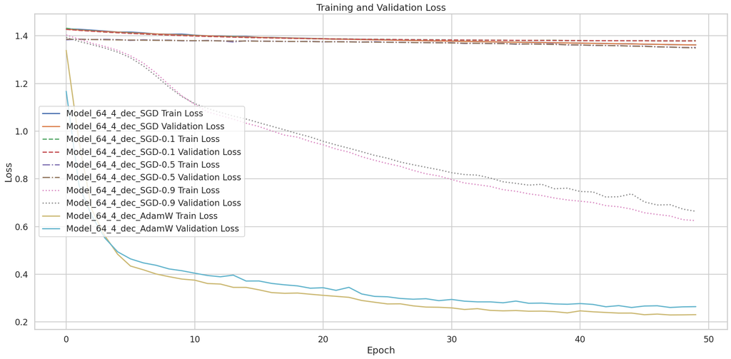

```python
batch_size = 64
fig, ax = plt.subplots(figsize=(20,10))

train_loader = DataLoader(train_dataset, batch_size=batch_size, shuffle=True)
val_loader = DataLoader(val_dataset, batch_size=batch_size, shuffle=False)
test_loader = DataLoader(test_dataset, batch_size=batch_size, shuffle=False)

for model, optimizer, style in zip(models, optimizers, styles[:5]):

    optim_name = f"_{optimizer.__class__.__name__}"
    if optim_name == "_SGD":
        momentum = optimizer.param_groups[0]['momentum']
        optim_name +=  f"-{momentum}" if momentum != 0 else ''

    training_loop(model, train_loader, val_loader, train_dataset, val_dataset, device, optimizer, criterion, num_epochs=50, optim_name=optim_name, style=style, ax=ax)
    reset_seed()

    testing_model(model, train_loader, device, "Training", optim_name=optim_name)
    testing_model(model, val_loader, device, "Validation", optim_name=optim_name)
    testing_model(model, test_loader, device, "Testing", optim_name=optim_name)
plt.savefig(f'./images/The_impact_of_the_Optimizer.pdf', bbox_inches='tight')
plt.show()
```

### Effect of the different learning rates and epochs

```python
lrs = [0.0005, 0.0001, 0.001, 0.01, 0.1]
num_epochs = [50, 100, 200]
```

```
========== Training Model_64_4_dec_AdamW_0.0005 ==========
The function took 29.2455 seconds to execute.
-> Model_64_4_dec_AdamW_0.0005 - Training Set
              precision    recall  f1-score   support

      Benign       0.99      0.90      0.95     10133
 Brute Force       0.77      0.95      0.85       856
    DoS Hulk       0.87      0.97      0.92      2321
    PortScan       0.25      0.90      0.39       171

    accuracy                           0.92     13481
   macro avg       0.72      0.93      0.78     13481
weighted avg       0.95      0.92      0.93     13481

-> Model_64_4_dec_AdamW_0.0005 - Validation Set
              precision    recall  f1-score   support

      Benign       0.99      0.90      0.94      3378
 Brute Force       0.79      0.94      0.86       285
    DoS Hulk       0.88      0.97      0.92       774
    PortScan       0.23      0.86      0.36        57

    accuracy                           0.92      4494
   macro avg       0.72      0.92      0.77      4494
weighted avg       0.95      0.92      0.93      4494

-> Model_64_4_dec_AdamW_0.0005 - Testing Set
              precision    recall  f1-score   support

      Benign       0.99      0.91      0.95      3378
 Brute Force       0.77      0.95      0.85       286
    DoS Hulk       0.88      0.95      0.91       773
    PortScan       0.25      0.84      0.38        57

    accuracy                           0.92      4494
   macro avg       0.72      0.91      0.77      4494
weighted avg       0.95      0.92      0.93      4494

========== Training Model_64_4_dec_AdamW_0.0001 ==========
The function took 28.8793 seconds to execute.
```

[output cut: 134 more lines]

```
    accuracy                           0.17      4494
   macro avg       0.04      0.25      0.07      4494
weighted avg       0.03      0.17      0.05      4494

-> Model_64_4_dec_AdamW_0.1 - Testing Set
              precision    recall  f1-score   support

      Benign       0.00      0.00      0.00      3378
 Brute Force       0.00      0.00      0.00       286
    DoS Hulk       0.17      1.00      0.29       773
    PortScan       0.00      0.00      0.00        57

    accuracy                           0.17      4494
   macro avg       0.04      0.25      0.07      4494
weighted avg       0.03      0.17      0.05      4494
```

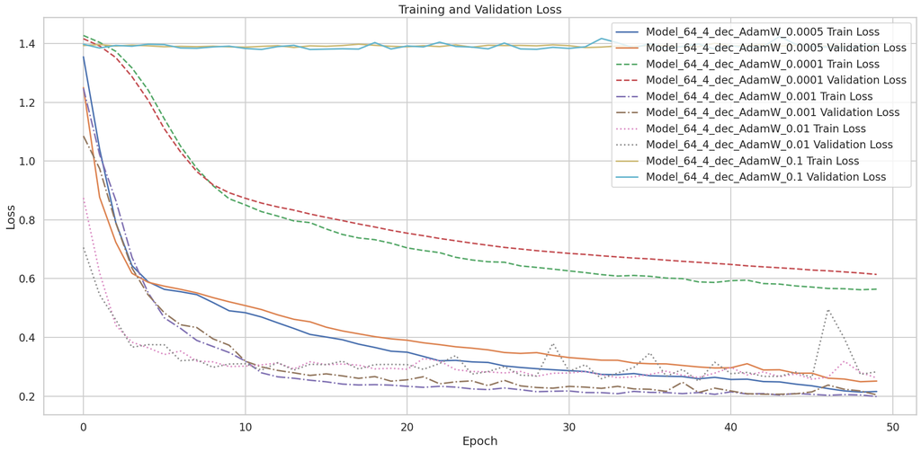

```
========== Training Model_64_4_dec_AdamW_0.0005 ==========
The function took 57.4984 seconds to execute.
-> Model_64_4_dec_AdamW_0.0005 - Training Set
              precision    recall  f1-score   support

      Benign       0.99      0.93      0.96     10133
 Brute Force       0.77      0.95      0.85       856
    DoS Hulk       0.93      0.93      0.93      2321
    PortScan       0.25      0.92      0.40       171

    accuracy                           0.93     13481
   macro avg       0.74      0.93      0.78     13481
weighted avg       0.96      0.93      0.94     13481

-> Model_64_4_dec_AdamW_0.0005 - Validation Set
              precision    recall  f1-score   support

      Benign       0.99      0.93      0.96      3378
 Brute Force       0.79      0.95      0.86       285
    DoS Hulk       0.92      0.91      0.92       774
    PortScan       0.22      0.86      0.35        57

    accuracy                           0.92      4494
   macro avg       0.73      0.91      0.77      4494
weighted avg       0.95      0.92      0.94      4494

-> Model_64_4_dec_AdamW_0.0005 - Testing Set
              precision    recall  f1-score   support

      Benign       0.99      0.92      0.96      3378
 Brute Force       0.75      0.95      0.84       286
    DoS Hulk       0.91      0.91      0.91       773
    PortScan       0.24      0.84      0.37        57

    accuracy                           0.92      4494
   macro avg       0.72      0.91      0.77      4494
weighted avg       0.95      0.92      0.93      4494

========== Training Model_64_4_dec_AdamW_0.0001 ==========
The function took 56.5426 seconds to execute.
```

[output cut: 134 more lines]

```
    accuracy                           0.75      4494
   macro avg       0.19      0.25      0.21      4494
weighted avg       0.57      0.75      0.65      4494

-> Model_64_4_dec_AdamW_0.1 - Testing Set
              precision    recall  f1-score   support

      Benign       0.75      1.00      0.86      3378
 Brute Force       0.00      0.00      0.00       286
    DoS Hulk       0.00      0.00      0.00       773
    PortScan       0.00      0.00      0.00        57

    accuracy                           0.75      4494
   macro avg       0.19      0.25      0.21      4494
weighted avg       0.57      0.75      0.65      4494
```

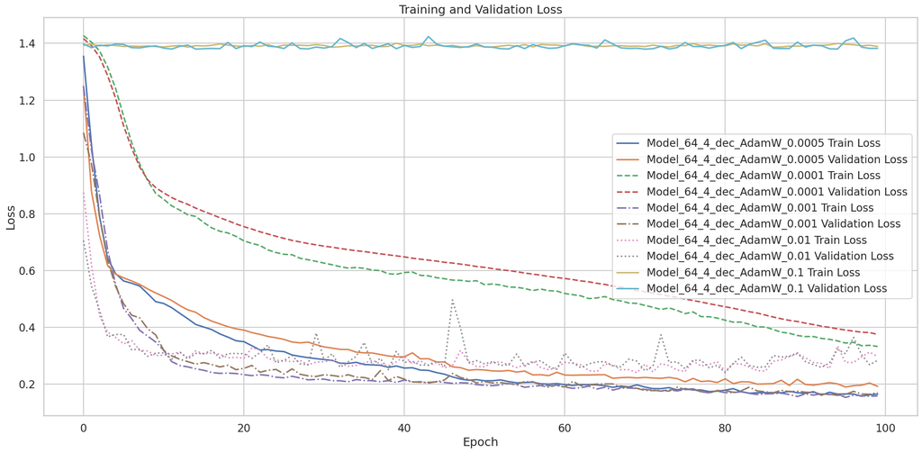

```
========== Training Model_64_4_dec_AdamW_0.0005 ==========
The function took 116.4286 seconds to execute.
-> Model_64_4_dec_AdamW_0.0005 - Training Set
              precision    recall  f1-score   support

      Benign       0.99      0.93      0.96     10133
 Brute Force       0.78      0.95      0.86       856
    DoS Hulk       0.93      0.95      0.94      2321
    PortScan       0.28      0.98      0.43       171

    accuracy                           0.93     13481
   macro avg       0.75      0.95      0.80     13481
weighted avg       0.96      0.93      0.94     13481

-> Model_64_4_dec_AdamW_0.0005 - Validation Set
              precision    recall  f1-score   support

      Benign       0.99      0.92      0.96      3378
 Brute Force       0.79      0.95      0.86       285
    DoS Hulk       0.92      0.95      0.93       774
    PortScan       0.26      0.95      0.41        57

    accuracy                           0.93      4494
   macro avg       0.74      0.94      0.79      4494
weighted avg       0.96      0.93      0.94      4494

-> Model_64_4_dec_AdamW_0.0005 - Testing Set
              precision    recall  f1-score   support

      Benign       0.99      0.93      0.96      3378
 Brute Force       0.75      0.95      0.84       286
    DoS Hulk       0.92      0.95      0.93       773
    PortScan       0.30      0.91      0.45        57

    accuracy                           0.93      4494
   macro avg       0.74      0.94      0.80      4494
weighted avg       0.95      0.93      0.94      4494

========== Training Model_64_4_dec_AdamW_0.0001 ==========
The function took 120.4311 seconds to execute.
```

[output cut: 134 more lines]

```
    accuracy                           0.17      4494
   macro avg       0.04      0.25      0.07      4494
weighted avg       0.03      0.17      0.05      4494

-> Model_64_4_dec_AdamW_0.1 - Testing Set
              precision    recall  f1-score   support

      Benign       0.00      0.00      0.00      3378
 Brute Force       0.00      0.00      0.00       286
    DoS Hulk       0.17      1.00      0.29       773
    PortScan       0.00      0.00      0.00        57

    accuracy                           0.17      4494
   macro avg       0.04      0.25      0.07      4494
weighted avg       0.03      0.17      0.05      4494
```

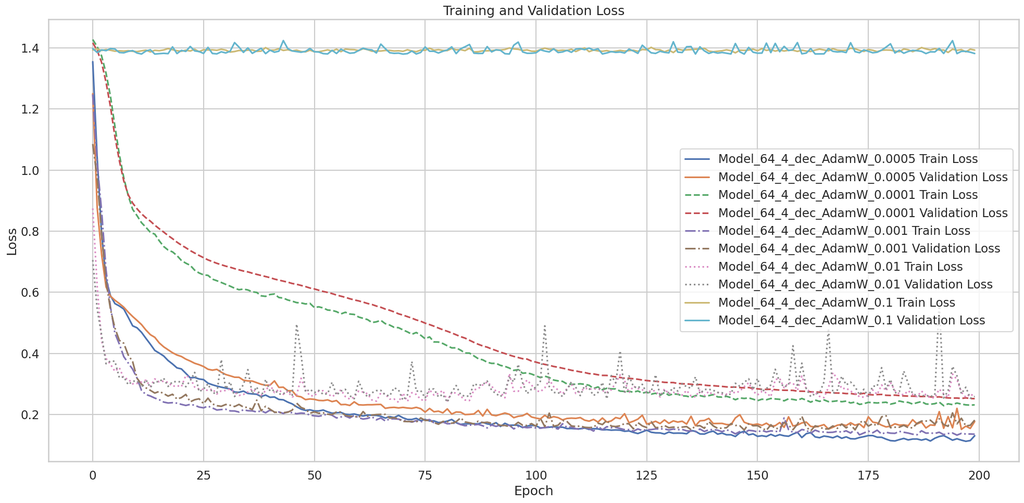

```python
batch_size = 64

train_loader = DataLoader(train_dataset, batch_size=batch_size, shuffle=True)
val_loader = DataLoader(val_dataset, batch_size=batch_size, shuffle=False)
test_loader = DataLoader(test_dataset, batch_size=batch_size, shuffle=False)

for n in num_epochs:
    fig, ax = plt.subplots(figsize=(20,10))

    models = [DeepNonLinearModel(15, 4, *best_hyperparameter).to(device) for _ in range(len(lrs))]
    criterion = nn.CrossEntropyLoss(weight=class_weights)
    optimizers = [optim.AdamW(model.parameters(), lr=lr) for model, lr in zip(models, lrs)]

    for model, optimizer, style in zip(models, optimizers, styles[:5]):

        optim_name = f"_{optimizer.__class__.__name__}"
        if optim_name == "_SGD":
            momentum = optimizer.param_groups[0]['momentum']
            optim_name +=  f"-{momentum}" if momentum != 0 else ''
        lr = optimizer.param_groups[0]['lr']
        optim_name += f"_{lr}"

        training_loop(model, train_loader, val_loader, train_dataset, val_dataset, device, optimizer, criterion, num_epochs=n, optim_name=optim_name, style=style, ax=ax)
        reset_seed()

        testing_model(model, train_loader, device, "Training", optim_name=optim_name)
        testing_model(model, val_loader, device, "Validation", optim_name=optim_name)
        testing_model(model, test_loader, device, "Testing", optim_name=optim_name)
    plt.savefig(f'./images/{n}-Effect_of_the_different_learning_rates_and_epochs.pdf', bbox_inches='tight')
    plt.show()
```